# SDS 315 HW 9

Suryabh Singh

2025-04-21

## Suryabh Singh

**Suryabh Singh** **ss229756** **GitHub Repository:** [GitHub Link](https://github.com/singhsuryabh/SDS-HW-9)

#Upload Dataset

```r
library(ggplot2)
library(dplyr)
set.seed(123)
solder <- read.csv("/Users/suryabhsingh/Desktop/SDS 315/solder.csv")
```

##**Problem 1**

**Part A**

```r
library(tidyverse)
head(solder)
```

```
##   Opening Solder Mask PadType Panel skips
## 1       L  Thick A1.5      W4     1     0
## 2       L  Thick A1.5      W4     2     0
## 3       L  Thick A1.5      W4     3     0
## 4       L  Thick A1.5      D4     1     0
## 5       L  Thick A1.5      D4     2     0
## 6       L  Thick A1.5      D4     3     0
```

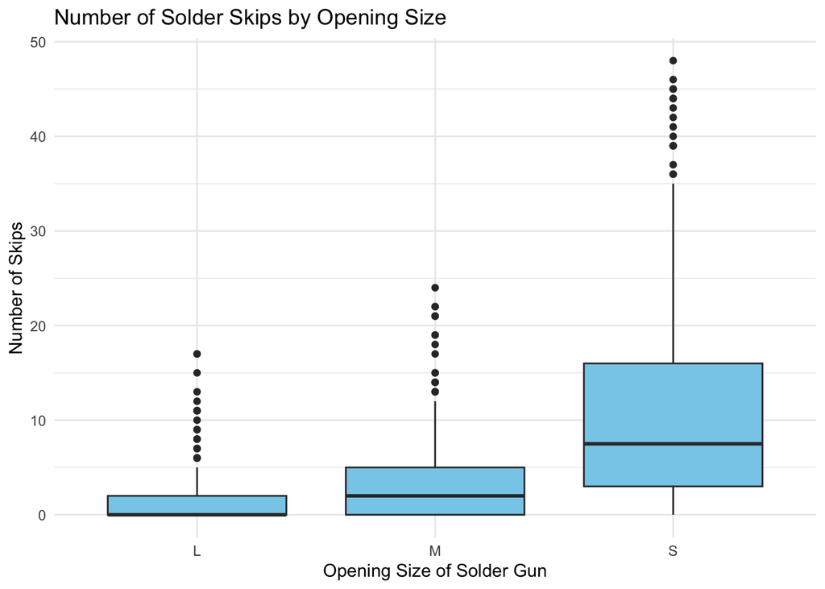

```r
# Plot: skips vs Opening
ggplot(solder, aes(x = Opening, y = skips)) +
  geom_boxplot(fill = "skyblue") +
  labs(title = "Number of Solder Skips by Opening Size",
       x = "Opening Size of Solder Gun",
       y = "Number of Skips") +
  theme_minimal()
```

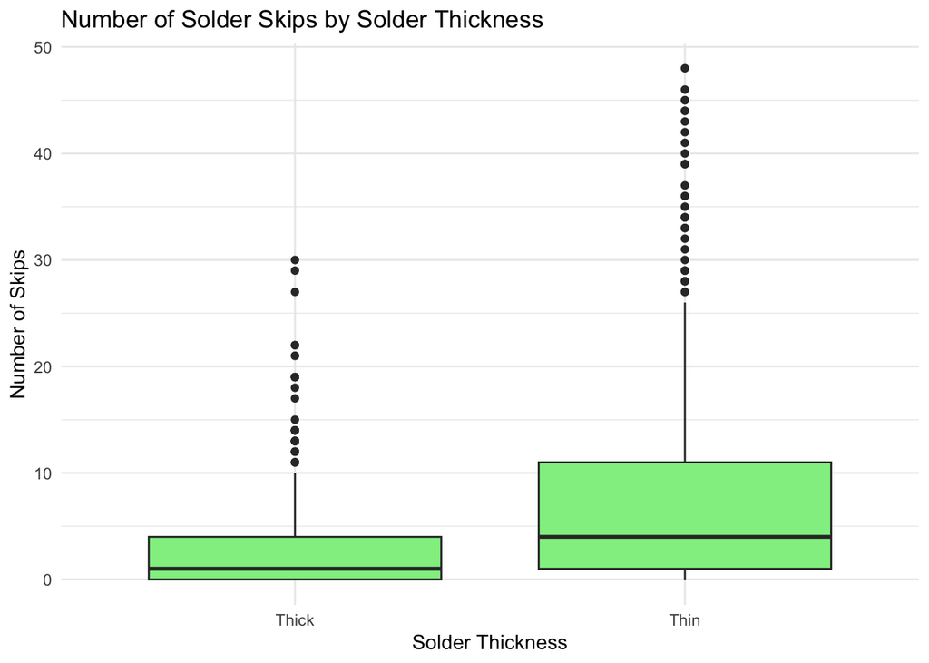

```r
# Plot: skips vs Solder
ggplot(solder, aes(x = Solder, y = skips)) +
  geom_boxplot(fill = "lightgreen") +
  labs(title = "Number of Solder Skips by Solder Thickness",
       x = "Solder Thickness",
       y = "Number of Skips") +
  theme_minimal()
```

**Part B**

```r
# Fit regression model with interaction
model <- lm(skips ~ Opening * Solder, data = solder)

# Summary table with 95% CI
library(broom)
tidy(model, conf.int = TRUE)
```

```
## # A tibble: 6 × 7
##   term                estimate std.error statistic  p.value conf.low conf.high
##   <chr>                  <dbl>     <dbl>     <dbl>    <dbl>    <dbl>     <dbl>
## 1 (Intercept)            0.393     0.520     0.756 4.50e- 1   -0.628      1.41
## 2 OpeningM               2.41      0.736     3.27  1.11e- 3    0.962      3.85
## 3 OpeningS               5.13      0.736     6.97  6.29e-12    3.68       6.57
## 4 SolderThin             2.28      0.736     3.10  2.01e- 3    0.836      3.72
## 5 OpeningM:SolderThin   -0.740     1.04     -0.711 4.77e- 1   -2.78       1.30
## 6 OpeningS:SolderThin    9.65      1.04      9.28  1.29e-19    7.61      11.7
```

**Part C**

- **Intercept:** The estimated average number of skips is the baseline at ~0.39.
- **Opening[T.M]:** Using medium instead of large opening (with thick solder) increases skips by ~2.41.
- **Opening[T.S]:** Using small instead of large opening (with thick solder) increases skips by ~5.13.
- **Solder[T.Thin]:** Using thin instead of thick solder (with large opening) increases skips by ~2.28.
- **Opening[T.M]:Solder[T.Thin]:** The interaction term reduces the expected increase when both medium opening and thin solder are used together, adjusting the additive effects by ~-0.74.

**Part D**

```r
# Compute average skips by group
solder %>%
  group_by(Opening, Solder) %>%
  summarise(mean_skips = mean(skips), .groups = "drop") %>%
  arrange(mean_skips)
```

```
## # A tibble: 6 × 3
##   Opening Solder mean_skips
##   <chr>   <chr>       <dbl>
## 1 L       Thick       0.393
## 2 L       Thin        2.67
## 3 M       Thick       2.8
## 4 M       Thin        4.34
## 5 S       Thick       5.52
## 6 S       Thin       17.5
```

Recommendation: Based on the lowest average number of skips, the Large Opening with Thick Solder combination is the most reliable and should be used to minimize manufacturing defects.